# RProgrammingWeek4.Rmd

Serge Ballif

May 22, 2016

## Simulation and Profiling

### `str` function

- a diagnostic function like `summary`
- well suited for compactly displaying large lists (even nested lists)
- gives one line of output per object

```r
str(str)
```

```
## function (object, ...)
```

```r
str(lm)
```

```
## function (formula, data, subset, weights, na.action, method = "qr",
##     model = TRUE, x = FALSE, y = FALSE, qr = TRUE, singular.ok = TRUE,
##     contrasts = NULL, offset, ...)
```

```r
x <- rnorm(100,2,4)
summary(x)
```

```
##    Min. 1st Qu.  Median    Mean 3rd Qu.    Max.
## -9.4660 -0.9044  1.9080  1.7730  4.3220 10.2700
```

```r
str(x)
```

```
##  num [1:100] 2.63 -4.54 2.55 4.79 -0.96 ...
```

```r
f <- gl(40,10)
str(f)
```

```
##  Factor w/ 40 levels "1","2","3","4",..: 1 1 1 1 1 1 1 1 1 1 ...
```

```r
summary(f)
```

```
##  1  2  3  4  5  6  7  8  9 10 11 12 13 14 15 16 17 18 19 20 21 22 23 24 25
## 10 10 10 10 10 10 10 10 10 10 10 10 10 10 10 10 10 10 10 10 10 10 10 10 10
## 26 27 28 29 30 31 32 33 34 35 36 37 38 39 40
## 10 10 10 10 10 10 10 10 10 10 10 10 10 10 10
```

```r
library(datasets)
head(airquality)
```

```
##   Ozone Solar.R Wind Temp Month Day
## 1    41     190  7.4   67     5   1
## 2    36     118  8.0   72     5   2
## 3    12     149 12.6   74     5   3
## 4    18     313 11.5   62     5   4
## 5    NA      NA 14.3   56     5   5
## 6    28      NA 14.9   66     5   6
```

```r
str(airquality)
```

```
## 'data.frame':    153 obs. of  6 variables:
##  $ Ozone  : int  41 36 12 18 NA 28 23 19 8 NA ...
##  $ Solar.R: int  190 118 149 313 NA NA 299 99 19 194 ...
##  $ Wind   : num  7.4 8 12.6 11.5 14.3 14.9 8.6 13.8 20.1 8.6 ...
##  $ Temp   : int  67 72 74 62 56 66 65 59 61 69 ...
##  $ Month  : int  5 5 5 5 5 5 5 5 5 5 ...
##  $ Day    : int  1 2 3 4 5 6 7 8 9 10 ...
```

```r
m <-matrix(rnorm(100),10,10)
str(m)
```

```
##  num [1:10, 1:10] 0.218 -0.043 0.404 0.221 -1.44 ...
```

```r
m[,1]
```

```
##  [1]  0.21825218 -0.04298577  0.40430202  0.22094141 -1.44029614
##  [6] -0.67335439  1.22743341  1.29497141  0.73125983 -0.30931339
```

```r
s <- split(airquality,airquality$Month)
str(s)
```

```
## List of 5
##  $ 5:'data.frame':   31 obs. of  6 variables:
##   ..$ Ozone  : int [1:31] 41 36 12 18 NA 28 23 19 8 NA ...
##   ..$ Solar.R: int [1:31] 190 118 149 313 NA NA 299 99 19 194 ...
##   ..$ Wind   : num [1:31] 7.4 8 12.6 11.5 14.3 14.9 8.6 13.8 20.1 8.6 ...
##   ..$ Temp   : int [1:31] 67 72 74 62 56 66 65 59 61 69 ...
##   ..$ Month  : int [1:31] 5 5 5 5 5 5 5 5 5 5 ...
##   ..$ Day    : int [1:31] 1 2 3 4 5 6 7 8 9 10 ...
##  $ 6:'data.frame':   30 obs. of  6 variables:
##   ..$ Ozone  : int [1:30] NA NA NA NA NA NA 29 NA 71 39 ...
##   ..$ Solar.R: int [1:30] 286 287 242 186 220 264 127 273 291 323 ...
##   ..$ Wind   : num [1:30] 8.6 9.7 16.1 9.2 8.6 14.3 9.7 6.9 13.8 11.5 ...
##   ..$ Temp   : int [1:30] 78 74 67 84 85 79 82 87 90 87 ...
##   ..$ Month  : int [1:30] 6 6 6 6 6 6 6 6 6 6 ...
##   ..$ Day    : int [1:30] 1 2 3 4 5 6 7 8 9 10 ...
##  $ 7:'data.frame':   31 obs. of  6 variables:
##   ..$ Ozone  : int [1:31] 135 49 32 NA 64 40 77 97 97 85 ...
##   ..$ Solar.R: int [1:31] 269 248 236 101 175 314 276 267 272 175 ...
##   ..$ Wind   : num [1:31] 4.1 9.2 9.2 10.9 4.6 10.9 5.1 6.3 5.7 7.4 ...
##   ..$ Temp   : int [1:31] 84 85 81 84 83 83 88 92 92 89 ...
##   ..$ Month  : int [1:31] 7 7 7 7 7 7 7 7 7 7 ...
##   ..$ Day    : int [1:31] 1 2 3 4 5 6 7 8 9 10 ...
##  $ 8:'data.frame':   31 obs. of  6 variables:
##   ..$ Ozone  : int [1:31] 39 9 16 78 35 66 122 89 110 NA ...
##   ..$ Solar.R: int [1:31] 83 24 77 NA NA NA 255 229 207 222 ...
##   ..$ Wind   : num [1:31] 6.9 13.8 7.4 6.9 7.4 4.6 4 10.3 8 8.6 ...
##   ..$ Temp   : int [1:31] 81 81 82 86 85 87 89 90 90 92 ...
##   ..$ Month  : int [1:31] 8 8 8 8 8 8 8 8 8 8 ...
##   ..$ Day    : int [1:31] 1 2 3 4 5 6 7 8 9 10 ...
##  $ 9:'data.frame':   30 obs. of  6 variables:
##   ..$ Ozone  : int [1:30] 96 78 73 91 47 32 20 23 21 24 ...
##   ..$ Solar.R: int [1:30] 167 197 183 189 95 92 252 220 230 259 ...
##   ..$ Wind   : num [1:30] 6.9 5.1 2.8 4.6 7.4 15.5 10.9 10.3 10.9 9.7 ...
##   ..$ Temp   : int [1:30] 91 92 93 93 87 84 80 78 75 73 ...
##   ..$ Month  : int [1:30] 9 9 9 9 9 9 9 9 9 9 ...
##   ..$ Day    : int [1:30] 1 2 3 4 5 6 7 8 9 10 ...
```

### Simulation - generating random numbers

- `rnorm`: generate random Normal variates with a given mean and standard deviation
- `dnorm`: evaluate the Normal probability density (with a given mean/SD) at a point (or vector of points)
- `pnorm`: evaluate the cumulative distribution function for a Normal distribution
- `rpois`: generate random Poisson variates with a given rate

Probability distribution functions usually have four functions associated with them. The functions are prefixed with a - `d` for density - `r` for random number generation - `p` for cumulative distribution - `q` for quantile function

Default values for norm:

```r
dnorm(x, mean = 0, sd = 1, log = FALSE)
pnorm(q, mean = 0, sd = 1, lower.tail = TRUE, log.p = FALSE)
qnorm(p, mean = 0, sd = 1, lower.tail = TRUE, log.p = FALSE)
rnorm(n, mean = 0, sd = 1)
```

```r
x <- rnorm(10)
x
```

```
##  [1]  0.43584918  0.57062217 -0.67360602  0.27917082 -0.90616084
##  [6]  0.07127524 -0.58485174 -1.22141797  0.48860771 -0.27732938
```

```r
x <- rnorm(10, 20, 2)
x
```

```
##  [1] 21.50303 18.54040 19.38271 21.01085 17.75223 18.95496 19.70273
##  [8] 13.60552 22.96652 15.77624
```

```r
summary(x)
```

```
##    Min. 1st Qu.  Median    Mean 3rd Qu.    Max.
##   13.61   17.95   19.17   18.92   20.68   22.97
```

```r
set.seed(1)
rnorm(5)
```

```
## [1] -0.6264538  0.1836433 -0.8356286  1.5952808  0.3295078
```

```r
rnorm(5)
```

```
## [1] -0.8204684  0.4874291  0.7383247  0.5757814 -0.3053884
```

```r
set.seed(1)
rnorm(5)
```

```
## [1] -0.6264538  0.1836433 -0.8356286  1.5952808  0.3295078
```

Generating Poisson data:

```r
rpois(10, 1)
```

```
##  [1] 0 0 1 1 2 1 1 4 1 2
```

```r
rpois(10, 2)
```

```
##  [1] 4 1 2 0 1 1 0 1 4 1
```

```r
rpois(10, 20)
```

```
##  [1] 19 19 24 23 22 24 23 20 11 22
```

```r
ppois(2, 2) ## Cumulative distribution P(X <=2)
```

```
## [1] 0.6766764
```

```r
ppois(4, 2) ## Pr(X <= 4)
```

```
## [1] 0.947347
```

```r
ppois(6, 2)## Pr(X <= 6)
```

```
## [1] 0.9954662
```

### Generating Random numbers from a model.

Suppose we want to simulate from the following linear model
$$y=\beta_0+\beta_1x+\varepsilon$$
where $\varepsilon\sim\mathcal{N}(0,2^2)$. Assume $x\sim \mathcal{N}(0,1^2)$, $\beta_0=0.5$ and $\beta_1=2$.

```r
set.seed(20)
x<- rnorm(100)
e=rnorm(100,0,2)
y <- 0.5+2*x+e
summary(y)
```

```
##    Min. 1st Qu.  Median    Mean 3rd Qu.    Max.
## -6.4080 -1.5400  0.6789  0.6893  2.9300  6.5050
```

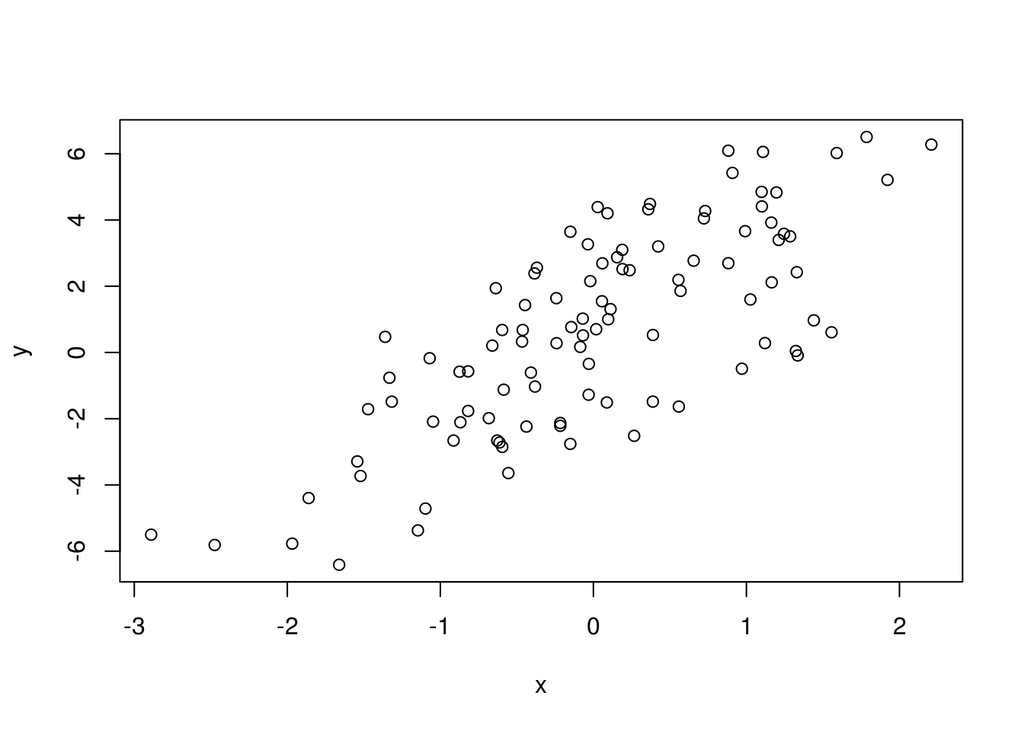

```r
plot(x,y)
```

How about if `x` is binary?

```r
set.seed(10)
x <- rbinom(100, 1, 0.5)
e <- rnorm(100, 0, 2)
y <- 0.5 + 2 * x + e
summary(y)
```

```
##    Min. 1st Qu.  Median    Mean 3rd Qu.    Max.
## -3.4940 -0.1409  1.5770  1.4320  2.8400  6.9410
```

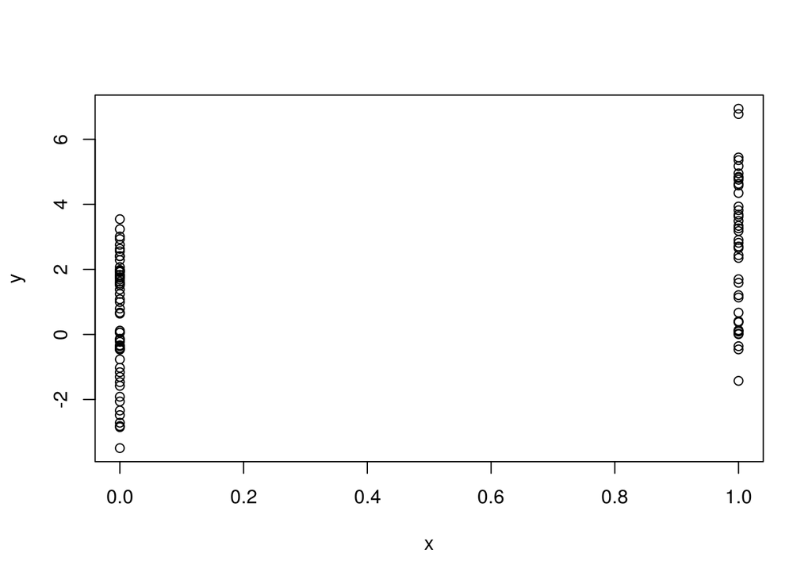

```r
plot(x,y)
```

Suppose we want to simulate from a Poisson model where $Y\sim\text{Poisson}(\mu)$, $\log \mu=\beta_0+\beta_1 x$.
$$y=\beta_0+\beta_1x+\varepsilon$$
and $\beta_0=0.5$ and $\beta_1=0.3$. We need to use the `rpois` function for this.

```r
set.seed(1)
x<-rnorm(100)
log.mu <- 0.5 + 0.3 * x
y <- rpois(100, exp(log.mu))
summary(y)
```

```
##    Min. 1st Qu.  Median    Mean 3rd Qu.    Max.
##    0.00    1.00    1.00    1.55    2.00    6.00
```

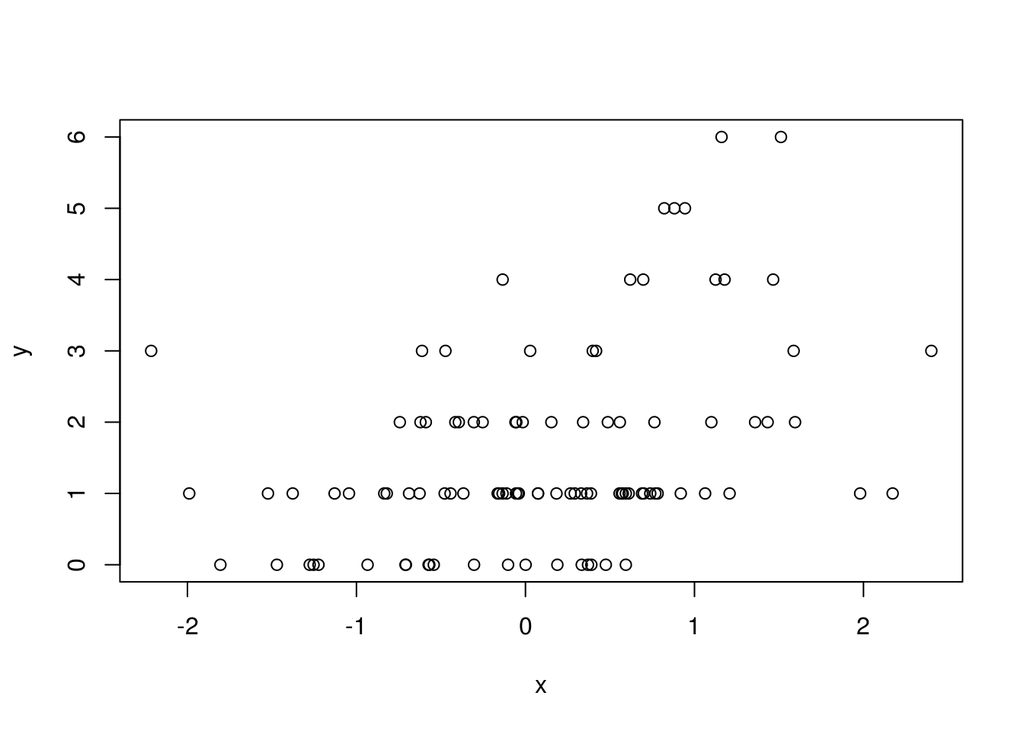

```r
plot(x,y)
```